# Unit10AssignmentCMorgan

ChrisMorgan

March 20, 2018

### HW10

```r
library(ggplot2)
library(RColorBrewer)
```

#### 1a

loads the data

```r
load(file="C:/Users/Chris/desktop/data.rda")
df<-mh2015_puf
```

#### 1b

creates unique state abbreviation list

```r
#states as a vector
states<-unique(df$LST)
states<-as.vector(states)
states
```

```
##  [1] "AL    " "AK    " "AZ    " "AR    " "CA    " "CO    " "CT    "
##  [8] "DE    " "DC    " "FL    " "GA    " "HI    " "ID    " "IL    "
## [15] "IN    " "IA    " "KS    " "KY    " "LA    " "ME    " "MD    "
## [22] "MA    " "MI    " "MN    " "MS    " "MO    " "MT    " "NE    "
## [29] "NV    " "NH    " "NJ    " "NM    " "NY    " "NC    " "ND    "
## [36] "OH    " "OK    " "OR    " "PA    " "RI    " "SC    " "SD    "
## [43] "TN    " "TX    " "UT    " "VT    " "VA    " "WA    " "WV    "
## [50] "WI    " "WY    " "AS    " "GU    " "PR    " "VI    "
```

#### 1c

Filter for VA hospitals in mainland U.S.

```r
#subsets for VA's only
VA<-subset(df,df$FACILITYTYPE=="Veterans Administration medical center (VAMC) or other VA health care facility")

# creates continental list (adds dc, eliminates Alaska and Hawaii)
continental<-c(state.abb,"DC")
removest<-c("AK","HI")
continental<-setdiff(continental,removest)

#trims whitespace from states
VA$LST<-trimws(VA$LST)

#searches for continental US states in VA dataframe and saves as new dataframe
VAST<-VA[as.character(VA$LST) %in% continental,]
stateVA<-as.data.frame(table(VAST$LST))
colnames(stateVA)<-c("State","Frequency")
stateVA
```

```
##    State Frequency
## 1     AL         4
## 2     AR         7
## 3     AZ         4
## 4     CA        18
## 5     CO         7
## 6     CT         1
## 7     DC         1
## 8     DE         1
## 9     FL        27
## 10    GA         9
## 11    IA         9
## 12    ID         5
## 13    IL        24
## 14    IN         7
```

[output cut: 34 more lines]

#### 1d

plotting for state VA hospital count

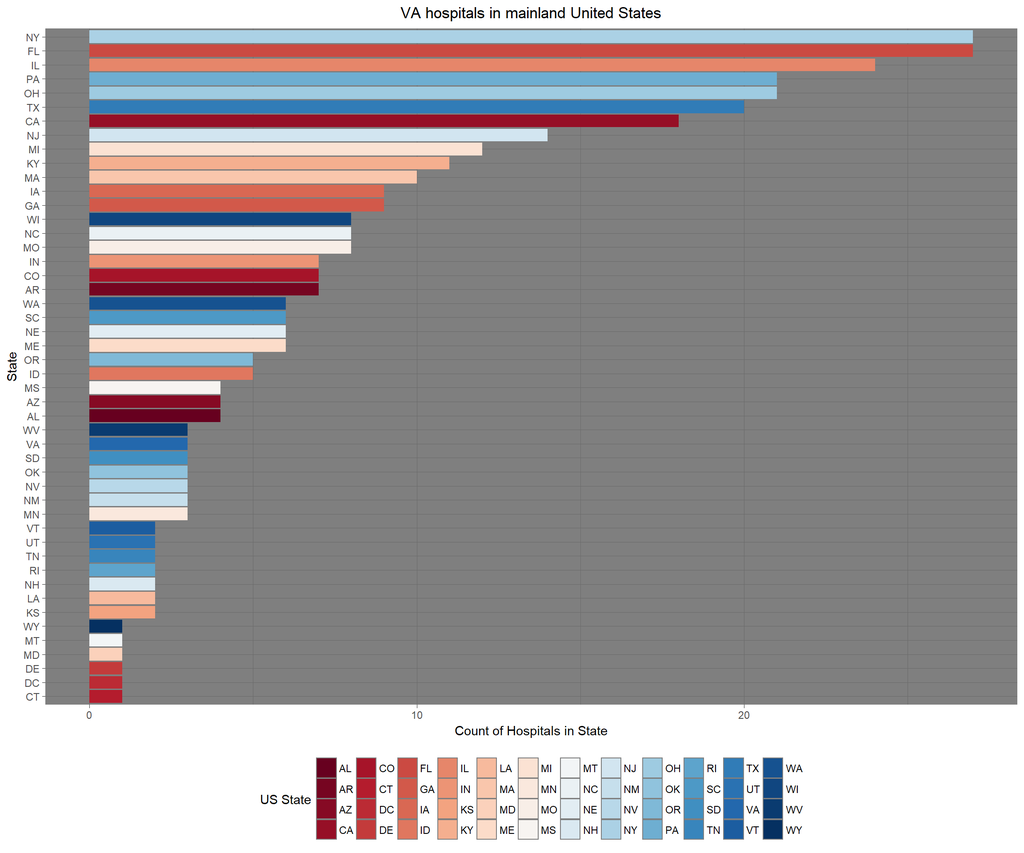

```r
#performs interpolation for color values to be used in ggplot
colourCount = length(unique(stateVA$State))
getPalette = colorRampPalette(brewer.pal(11, "RdBu"))

#plots states
ggplot(data = stateVA, aes(x=reorder(stateVA$State,stateVA$Frequency),y=stateVA$Frequency,fill=stateVA$State)) +
  geom_bar(stat="identity") + coord_flip() + theme_dark() +
  labs(title="VA hospitals in mainland United States",x="State",y="Count of Hospitals in State") +
  theme(plot.title = element_text(hjust = 0.5), legend.position = "bottom") +
  guides(fill=guide_legend(title="US State",nrow=4))+ scale_fill_manual(values = getPalette(colourCount))
```

#### 2a

import statesize, and show why pasting data together is a bad idea

```r
#reads in state size data
ss<-read.csv("C:/Users/Chris/documents/R/Working directory/6306/Unit 10/statesize.csv")
colnames(ss)<-c("StateName","SqMiles","State","Region")


#paste data together for demo 2a
paste(stateVA$State[1:5], ss$StateName[1:5], ss$SqMiles[1:5])
```

```
## [1] "AL Alabama 50750"     "AR Alaska 570374"     "AZ Arizona 113642"
## [4] "CA Arkansas 52075"    "CO California 155973"
```

```r
#We can see this is a bad idea as the values do not line up and the state data includes some states we previously eliminated. #using paste for joining dataframe's generally isn't advisable compared to other methods like merge...
#i previously did trim ws space previously, this may have presented more problems at this step.
```

We can see this is a bad idea as the values do not line up and the state data includes some states we previously eliminated. Using paste for joining data frame’s generally isn’t advisable compared to other methods like “merge”…I previously did trim ws space around the state abbreviations, this may have presented more problems at this step.

#### 2b

merge data in a logical way

```r
#merges statedf and states size data
zz<-merge(stateVA,ss,by="State")
```

#### 2c

create metric for hospitals per 1,000 miles

```r
#calculate per 1000 sq miles
zz$hptho<-(zz$Frequency/zz$SqMiles)*1000
```

#### 2d

plotting for hospitals per 1,000 miles relative to US region

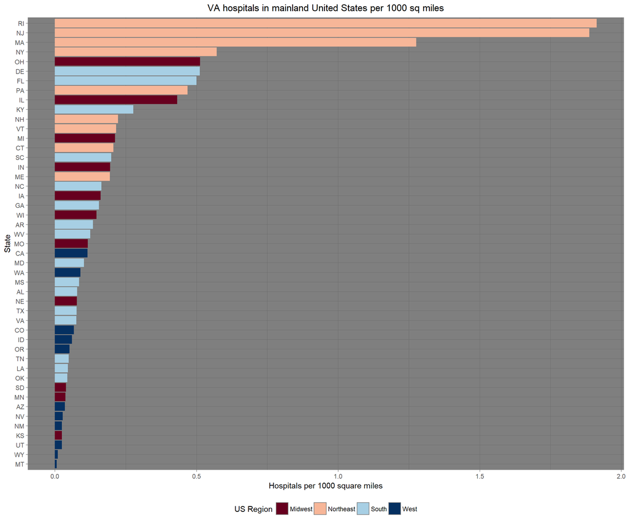

```r
#performs interpolation for color values to be used in ggplot
colourCount2 = length(unique(zz$Region))

#plots hospitals for region
ggplot(data = zz, aes(x=reorder(zz$State,zz$hptho),y=zz$hptho,fill=zz$Region)) +
  geom_bar(stat="identity") + coord_flip() + theme_dark() +
  labs(title="VA hospitals in mainland United States per 1000 sq miles",x="State",y="Hospitals per 1000 square miles") +
  theme(plot.title = element_text(hjust = 0.5), legend.position = "bottom") +
  guides(fill=guide_legend(title="US Region",nrow=1)) + scale_fill_manual(values = getPalette(colourCount2))
```

#### 2e

We see smaller states in the northeast have more hospitals per 1000 sq miles, which is in line with what we’d expect given the northeast is known to be more dense in population in general. On the opposite end, we see the Western region as being very low on hospitals per 1,000 miles. While this may bring concerns to some, this may be justifiable since these regions are typically less dense in population.

Because of this, i think it would be wise to include population density for states and ability to travel to hospitals in the region (potentially by examining average travel time). Other metrics like veterans/eligible user population relative to hospital capacity would merit investigation (i.e. hospital beds within 500 miles relative to eligible patients)